# Lab09: Inferência para dados categóricos

## Introdução

Em agosto de 2012, agências de notícias que vão do [Washington Post](https://www.washingtonpost.com/national/on-faith/poll-shows-atheism-on-the-rise-in-the-us/2012/08/13/90020fd6-e57d-11e1-9739-eef99c5fb285_story.html) ao [Huffington Post](https://www.huffpost.com/entry/atheism-rise-religiosity-decline-in-america_n_1777031) publicaram um texto sobre a ascensão do ateísmo na América. A fonte do artigo foi uma pesquisa que perguntou às pessoas: “Independentemente de você frequentar um local de culto ou não, você diria que é uma pessoa religiosa, não religiosa ou ateu convicto?” Esse tipo de pergunta, que pede que as pessoas se classifiquem de uma forma ou de outra, é comum em enquetes e gera dados categóricos. Neste laboratório, damos uma olhada na pesquisa de ateísmo e exploramos o que está em jogo ao fazer inferências sobre proporções populacionais usando dados categóricos.

```r
library(ggplot2)
library(plyr)
library(tidyr)
library(dplyr)
library(DescTools)
library(htmltools)
library(knitr)
library(rmarkdown)
library(combinat)
library(kableExtra) #Para gerar tabelas com um layout agradável
```

## Conteúdos abordados neste laboratório

- Teorema do Limite Central
- Distribuição Normal Padrão
- Intervalo de Confiança para a Proporção
- Amostragem

## A pesquisa

Para baixar uma cópia da *release* da pesquisa, realizada pela WIN-Gallup International, clique no seguinte link:

[release to Global index of religiosity and atheism](https://www.webpages.uidaho.edu/~stevel/251/Global_INDEX_of_Religiosity_and_Atheism_PR__6.pdf)

Reserve um momento para revisar o relatório e, em seguida, responda às seguintes perguntas.

> Exercício 1: No primeiro parágrafo, várias descobertas importantes são relatadas. Essas porcentagens parecem ser estatísticas amostrais (derivadas dos dados amostrais) ou parâmetros populacionais?

Essas porcentagens são estatísticas amostrais, as quais estão sendo usadas, no resultado da pesquisa, para fazer inferência acerca dos respectivos parâmetros populacionais.

> Exercício 2: O título do relatório é “Índice Global de Religiosidade e Ateísmo”. Para generalizar as descobertas do relatório para a população humana global, o que devemos supor sobre o método de amostragem? Isso parece uma suposição razoável?

Para fazer essa generalização, precisamos supor que a amostra coletada reflete o comportamento das populações de interesse. Para isso, o processo de amostragem precisa ser aleatório, bem como englobar todos os estratos da população.

No caso da pesquisa em análise, essa suposição parece ser válida apenas parcialmente, uma vez que foi selecionada uma amostra de tamanho $n \approx 50000$ pessoas em 57 diferentes países. Porém, não foi especificado no texto se foi considerado algum tipo de estratificação no processo de amostragem.

Além disso, outro possível problema com o método de amostragem utilizado é o fato de parte da pesquisa ter sido realizada por meio de telefone e/ou internet. Esse tipo de seleção do público alvo pode gerar um viés de seleção, uma vez que, uma pequena parcela da população possui telefone e nem todos possuem acesso à internet.

## Os dados

Volte sua atenção para a Tabela 6 (páginas 15 e 16), que relata o tamanho da amostra e as porcentagens de resposta para todos os 57 países. Embora este seja um formato útil para resumir os dados, basearemos nossa análise no conjunto de dados original de respostas individuais à pesquisa. Carregue este conjunto de dados no R com o seguinte comando.

```r
download.file("http://www.openintro.org/stat/data/atheism.RData", destfile = "atheism.RData")
load("atheism.RData")
```

Para investigar a ligação entre essas duas formas de organizar esses dados, dê uma olhada na proporção estimada de ateus nos Estados Unidos. No final da Tabela 6, vemos que isso é 5%. Devemos ser capazes de chegar ao mesmo número usando o conjunto de dados `atheism`, o que pode ser conseguido facilmente com as funções da biblioteca `dplyr` ou com a função `subset()`, que é nativa do R:

```r
atheism %>%
  filter(nationality == "United States", year == 2012) %>%
  select(response) %>%
  table() %>%
  prop.table()
```

```
## response
##     atheist non-atheist
##   0.0499002   0.9500998
```

Nesse caso, usamos também a função `table()`, já introduzida em outros laboratórios, para calcular a proporção desejada, que vemos que está de acordo com a proporção dada na tabela da release.

## Inferência sobre proporções

Como foi sugerido no Exercício 1, a Tabela 6 fornece estatísticas , ou seja, cálculos feitos a partir da amostra de 51.927 pessoas. O que gostaríamos, porém, é de uma visão dos parâmetros da população . Você responde à pergunta: *“Qual proporção de pessoas em sua amostra relatou ser ateia?”* com uma estatística; enquanto a pergunta *“Qual a proporção de pessoas na Terra diriam ser ateus”* é respondida com uma estimativa do parâmetro.

As ferramentas inferenciais para estimar a proporção da população são análogas àquelas usadas para médias no último capítulo: o intervalo de confiança e o teste de hipótese. Aqui, igualmente como no caso citado, também se aplica o teorema de limite central, já que a proporção é também uma média!

> Exercício 3: Escreva as condições de inferência para construir um intervalo de confiança de 95% para a proporção de ateus nos Estados Unidos em 2012. Você tem certeza de que todas as condições foram atendidas?

Se as condições para inferência forem razoáveis, podemos calcular o erro padrão e construir o intervalo “manualmente”, conforme descrito em nosso livro. Observe que, como o objetivo é construir uma estimativa de intervalo para uma proporção, é necessário especificar o que constitui um “sucesso”, que aqui é uma resposta de “atheist”.

Primeiro, vamos salvar as respostas da pesquisa de 2012 para as pessoas dos Estados Unidos. Em seguida, vamos calcular a estatística desejada, que é $\hat{p}$:

```r
#Filtrando os dados da pesquisa para Estados Unidos
us12 = atheism %>%
  filter(nationality == "United States", year == 2012) %>%
  select(response)

#Transformando a resposta em binária
atheist_yes_no = us12$response == "atheist"

#Cálculo da proporção de sucessos na amostra
p_hat = mean(atheist_yes_no)

#Construção do IC
n = length(atheist_yes_no)
std_err = sqrt(p_hat*(1-p_hat)/n)
z = qnorm(0.975)
IC = p_hat + c(-1,1)*z*std_err
```

Embora intervalos de confiança formais e testes de hipóteses não apareçam na release, sugestões de inferência aparecem no final da página 7: “Em geral, a margem de erro para pesquisas desse tipo é de $\pm 3-5 \%$, com 95% de nível confiança”.

> Exercício 4: Com base no trabalho acima, qual é a margem de erro para a estimativa da proporção de ateus nos EUA em 2012?

A margem de erro é matematicamente igual àquilo que vem após o +/- na expressão do IC. Dessa forma, no atual caso, é igual a 0.0134819, ou seja, cerca de 1,3%.

> Exercício 5: Calcule intervalos de confiança para a proporção de ateus em 2012 em dois outros países de sua escolha e relate as margens de erro associadas. Certifique-se de observar se as condições para inferência são atendidas. Pode ser útil criar primeiro novos conjuntos de dados para cada um dos dois países e, em seguida, usar esses conjuntos de dados durante os cálculos.

Para responder a esse item, vamos replicar os cálculos feitos logo acima para os dois países escolhidos: Brazil e India.

```r
#Primeira escolha: Brazil
#Filtrando os dados da pesquisa para o Brasil
br12 = atheism %>%
  filter(nationality == "Brazil", year == 2012) %>%
  select(response)

#Transformando a resposta em binária
atheist_yes_no = br12$response == "atheist"

#Cálculo da proporção de sucessos na amostra
p_hat = mean(atheist_yes_no)

#Construção do IC
n = length(atheist_yes_no)
std_err = sqrt(p_hat*(1-p_hat)/n)
z = qnorm(0.975)
IC = p_hat + c(-1,1)*z*std_err
margin_err = z*std_err
```

```r
#Relatando os dados para o Brazil:
cat(
  " Dados para o Brasil:\n\n",
  "Tamanho da amostra:",
  n,
  "\n",
  "IC:",
  IC,
  "\n",
  "Margem de erro:",
  margin_err
    )
```

```
##  Dados para o Brasil:
##
##  Tamanho da amostra: 2002
##  IC: 0.0056337 0.01434632
##  Margem de erro: 0.00435631
```

```r
#Segunda escolha: India
#Filtrando os dados da pesquisa para a India
ind12 = atheism %>%
  filter(nationality == "India", year == 2012) %>%
  select(response)

#Transformando a resposta em binária
atheist_yes_no = ind12$response == "atheist"

#Cálculo da proporção de sucessos na amostra
p_hat = mean(atheist_yes_no)

#Construção do IC
n = length(atheist_yes_no)
std_err = sqrt(p_hat*(1-p_hat)/n)
z = qnorm(0.975)
IC = p_hat + c(-1,1)*z*std_err
margin_err = z*std_err
```

```r
#Relatando os dados para a India:
cat(
  " Dados para a India:\n\n",
  "Tamanho da amostra:",
  n,
  "\n",
  "IC:",
  IC,
  "\n",
  "Margem de erro:",
  margin_err
    )
```

```
##  Dados para a India:
##
##  Tamanho da amostra: 1092
##  IC: 0.0200662 0.04037336
##  Margem de erro: 0.01015358
```

Um exercício interessante aqui é replicar o trecho de código acima e escolher outros países.

## Como a proporção afeta a margem de erro?

Imagine que você decidiu fazer uma pesquisa com 1.000 pessoas sobre duas perguntas: *você é mulher?* e *você é canhoto?* Como ambas as proporções amostrais foram calculadas a partir do mesmo tamanho de amostra, elas devem ter a mesma margem de erro, certo? Errado! Embora a margem de erro mude com o tamanho da amostra, ela também é afetada pela proporção.

Pense na fórmula do erro padrão:

$$SE = \sqrt{p*(1-p)/n}.$$

Esse resultado é então usado na fórmula para a margem de erro que, para um intervalo de confiança de 95%, será dada por:

$$ME = 1.96*SE = 1.96*\sqrt{p*(1-p)/n}.$$

Vemos então que a margem de erro depende da proporção da população. Podemos visualizar essa relação criando um gráfico de $ME$ contra $p$.

O primeiro passo é fazer um vetor `p` que seja uma sequência de 0 a 1, com cada número separado por 0,01. Podemos então criar um vetor da margem de erro (`ME`) associado a cada um desses valores usando a conhecida fórmula aproximada ($ME \approx 1.96*SE$). Por fim, plotamos os dois vetores um contra o outro para revelar sua relação.

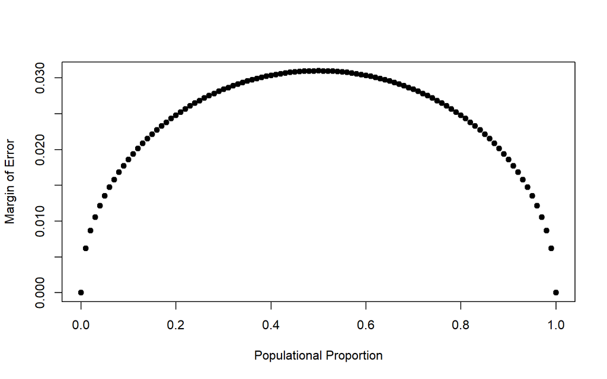

```r
n = 1000 #Tamanho simulado da amostra
p = seq(0, 1, 0.01)
ME = 1.96*sqrt(p*(1-p)/n)

plot(
  p,
  ME,
  xlab = "Populational Proportion",
  ylab = "Margin of Error",
  pch = 19
)
```

> Exercício 6: Descreva a relação entre `p` e `ME`.

Como vemos, e como é esperado, a margem de erro do intervalo de confiança para a proporção é máxima quando $p = 0.5$, assim como acontece com o erro padrão do estimador.

## Condição de sucesso-falha

O livro enfatiza que você deve sempre verificar as condições antes de fazer inferências. Para inferência sobre proporções, a proporção da amostra pode ser considerada quase normal se for baseada em uma amostra aleatória de observações independentes e se ambas as expressões a seguir forem válidas:

$$np \geq 10$$

$$np*(1-p) \geq 10$$

Essa regra prática é fácil de seguir, mas nos faz pensar: o que há de tão especial no número 10?

A resposta curta é: nada. Você poderia argumentar que estaríamos bem com 9 ou que realmente deveríamos usar 11. Qual é o “melhor” valor para tal regra prática é, pelo menos até certo ponto, arbitrário. No entanto, quando $np$ e $np*(1-p)$ atinge 10, a distribuição amostral é suficientemente normal para usar intervalos de confiança e testes de hipóteses baseados nessa aproximação.

Podemos investigar a interação entre $n$, $p$ e a forma da distribuição amostral usando simulações. Para começar, simulamos o processo de extração de 5.000 amostras de tamanho 1.040 de uma população com uma proporção de verdadeiros ateus de 0,1. Para cada uma das 5.000 amostras, calculamos $\hat{p}$ e, em seguida, traçamos um histograma para visualizar sua distribuição.

Para fazer a simulação, vamos usar a função `rdply()` da biblioteca `plyr`, já utilizada nos capítulos 4 e 5.

```r
set.seed(123)
p = 0.1
n = 1040
sample_p_hat = rdply(
  5000,
  .expr = data.frame(
    sample = sample(c("atheist", "non_atheist"), n, replace = T, prob = c(p, 1-p))
  ),
  .id = "id_sample"
) %>%
  group_by(id_sample) %>%
  summarise(phat = mean(sample == "atheist"))
```

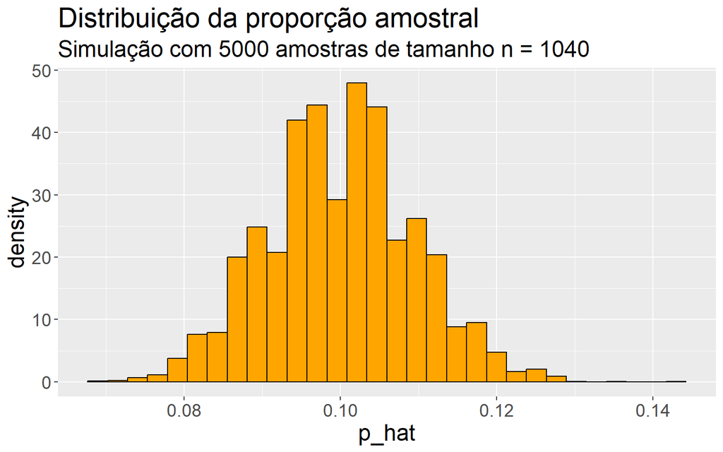

```r
sample_p_hat %>%
  ggplot(aes(x = phat)) +
  geom_histogram(
    aes(y = after_stat(density)),
    fill = "orange",
    col = "black"
  ) +
  labs(
    x = "p_hat",
    title = "Distribuição da proporção amostral",
    subtitle = "Simulação com 5000 amostras de tamanho n = 1040"
  ) +
  theme(text = element_text(size = 18))
```

> Exercício 7: Descreva a distribuição amostral da proporção amostra para $n = 1040$ e $p = 0,1$. Certifique-se de observar o centro, dispersão e forma. Dica: Lembre-se de que o R tem funções como `mean` para calcular estatísticas resumidas.

A forma da distribuição amostral obtida é aproximadamente normal. Vamos calcular a média a variância e comparar com $p$ e $\sqrt{p*(1-p)/n}$, respectivamente.

```r
sample_p_hat %>%
  summarise(
    xbar = mean(phat),
    var = sd(phat)^2
  ) %>%
  kable() %>%
  kable_styling(
    full_width = F,
    bootstrap_options = c("striped", "hover", "condensed",
                          "responsive")
  )
```

| xbar | var |
| --- | --- |
| 0.1000038 | 8.86e-05 |

Temos então $\bar{x} \approx p$ e $s^2 \approx p*(1-p)/1040$.

> Exercício 8: Repita a simulação acima mais três vezes, mas com tamanhos e proporções de amostra modificados: para $n = 400$ e $p = 0,1$, $n = 1040$ e $p = 0,02$ e $n = 400$ e $p = 0,02$. Plote os histogramas lado a lado. Descreva as três novas distribuições amostrais. Com base nesses gráficos, como $n$ parece afetar a distribuição de $\hat{p}$? Como $p$ afeta a distribuição amostral?

Primeiramente, vamos replicar o trecho de código utilizado para gerar as amostras:

```r
# n = 400 e p = 0,1
set.seed(123)
p = 0.1
n = 400
sample_phat_400_0.1 = rdply(
  5000,
  .expr = data.frame(
    sample = sample(c("atheist", "non_atheist"), n, replace = T, prob = c(p, 1-p))
  ),
  .id = "id_sample"
) %>%
  group_by(id_sample) %>%
  summarise(phat = mean(sample == "atheist"))


# n = 1040 e p = 0,02
set.seed(123)
p = 0.02
n = 1040
sample_phat_1040_0.02 = rdply(
  5000,
  .expr = data.frame(
    sample = sample(c("atheist", "non_atheist"), n, replace = T, prob = c(p, 1-p))
  ),
  .id = "id_sample"
) %>%
  group_by(id_sample) %>%
  summarise(phat = mean(sample == "atheist"))


# n = 400 e p = 0,02
set.seed(123)
p = 0.02
n = 400
sample_phat_400_0.02 = rdply(
  5000,
  .expr = data.frame(
    sample = sample(c("atheist", "non_atheist"), n, replace = T, prob = c(p, 1-p))
  ),
  .id = "id_sample"
) %>%
  group_by(id_sample) %>%
  summarise(phat = mean(sample == "atheist"))
```

Agora, vamos agrupar os 3 conjuntos de dados em um único dataframe, a fim de facilitar o processo de plotagem:

```r
sample_phat = rbind(
  sample_phat_400_0.1,
  sample_phat_1040_0.02,
  sample_phat_400_0.02
) %>%
  select(-id_sample) %>%
  mutate(
    np = rep(c("[400; 0,1]", "[1040; 0,02]", "[400; 0,02]"), each = 5000)
  )
```

Finalmente, vamos plotar os histogramas:

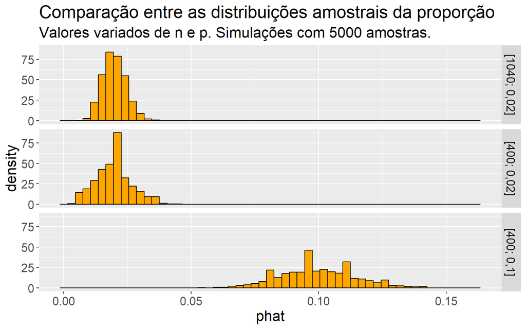

```r
sample_phat %>%
  ggplot(aes(x = phat)) +
  geom_histogram(
    fill = "orange",
    col = "black",
    binwidth = 0.003,
    aes(y = after_stat(density))
    ) +
  facet_wrap(~np, ncol = 1, strip.position = "right") +
  labs(
    title = "Comparação entre as distribuições amostrais da proporção",
    subtitle = "Valores variados de n e p. Simulações com 5000 amostras."
  ) +
  theme(text = element_text(size = 16))
```

Como vemos nos gráficos plotados, todas as três distribuições são aproximadamente normais. Além disso, vemos que, dado o tamanho $n$ da amostra fixo, quanto maior o valor de $p$, maior a média da distribuição de $\hat{p}$ e maior a dispersão da distribuição. Por outro lado, dado o valor de $p$ fixo, quanto maior o valor de $n$, menor a distribuição amostral. Todas essas observações são compatíveis com a conclusão do teorema de limite central de que, para n suficientemente grande,

$$\hat{p} \sim N \left(p, p*(1-p)/n
\right).$$

> Exercício 9: Se você consultar a Tabela 6, verá que a Austrália tem uma proporção amostral de 0,1 em um tamanho de amostra de 1.040, e que o Equador tem uma proporção amostral de 0,02 em 400 indivíduos. Vamos supor para este exercício que essas estimativas pontuais são realmente verdadeiras. Então, dada a forma de suas respectivas distribuições amostrais, você acha que é sensato prosseguir com a inferência e relatar a margem de erros, como o relatório faz? – Verificando nossa condição de pelo menos 10 sucessos e falhas observados.

Analisando a situação dada para Austrália e Equador de acordo com os resultados dos gráficos acima, bem como tendo em vista as condições $np \geq 10$ e $np*(1-p) \geq 10$, conclui-se que o tamanho amostral utilizado para o Equador não parece ser adequado, já que não seria suficiente para cumprir essas duas condições.

## Por sua conta

A questão do ateísmo foi feita pela WIN-Gallup International em uma pesquisa semelhante realizada em 2005. (Presumimos aqui que os tamanhos das amostras permaneceram os mesmos - ou próximos o suficiente, de modo que realmente não importa.) A tabela 4 na página 13 da release resume os resultados da pesquisa de 2005 e 2012 para 39 países.

Responda às duas perguntas a seguir usando intervalos de confiança calculados “manualmente” ou usando as funções integradas descritas na seção final do laboratório. Como sempre, escreva as hipóteses para quaisquer testes que realizar e descreva o status das condições para inferência.

1. Existem evidências convincentes de que a Espanha viu uma mudança em seu índice de ateísmo entre 2005 e 2012? Dica: crie um novo conjunto de dados para entrevistados da Espanha para 2005 e 2012. Forme intervalos de confiança para a verdadeira proporção de ateus em ambos os anos e determine se eles se sobrepõem.

Para responder a essa questão, vamos usar as funções `prop.test()` e `binom.test()`, conforme comentários na próxima seção. A função `prop.test()` vai nos ajudar a verificar ou não a hipótese de que o índice de ateísmo na Espanha mudou entre uma amostragem e outra. No caso em análise, vamos passar como argumentos para a função os dois grupos (amostra de 2005 e de 2012) e `alternative = two.sided`, de acordo com as hipóteses nulas e alternativas descritas a seguir:

$$H_0: p_{2005} = p_{2012}$$

$$H_1: p_{2005} \neq p_{2012}$$

Primeiro, vamos fazer o teste de hipóteses usando a função `prop.test()`. Para isso, devemos lembrar que sua implementação se baseia no teorema do limite central e, dessa forma, seu resultado é uma aproximação que depende do tamanho das amostras utilizadas. Para fazer esse teste, vamos determinar o número de sucessos em cada caso (ou seja, o número de ateus) e os respectivos números de tentativas:

```r
#2012
response_esp_2012 = atheism %>%
  filter(nationality == "Spain", year == 2012) %>%
  select(response)

n_esp_2012 = nrow(response_esp_2012)
ateus_esp_2012 = sum(response_esp_2012$response == "atheist")


#2005
response_esp_2005 = atheism %>%
  filter(nationality == "Spain", year == 2005) %>%
  select(response)

n_esp_2005 = nrow(response_esp_2005)
ateus_esp_2005 = sum(response_esp_2005$response == "atheist")
```

Agora, faremos os testes propriamente ditos:

```r
#Usando a função prop.test()
prop.test(
  x = c(ateus_esp_2005, ateus_esp_2012),
  n = c(n_esp_2005, n_esp_2012)
  )
```

```
##
##  2-sample test for equality of proportions with continuity correction
##
## data:  c(ateus_esp_2005, ateus_esp_2012) out of c(n_esp_2005, n_esp_2012)
## X-squared = 0.60285, df = 1, p-value = 0.4375
## alternative hypothesis: two.sided
## 95 percent confidence interval:
##  -0.01450680  0.03529222
## sample estimates:
##     prop 1     prop 2
## 0.10034904 0.08995633
```

Conforme o p-valor obtido, decidimos então que, com essas amostras, não podemos rejeitar a hipótese nula de que o percentual de ateus na Espanha se manteve nas duas pesquisas. Vendo também do ponto de vista do intervalo de confiança, o resultado nos mostra que o IC de 95% para a diferença entre as duas proporções contêm o zero, o que corrobora com a afirmação já dada na frase anterior.

Para comparar o resultado, vamos obter os intervalos de confiança exatos individuais para cada proporção:

```r
#Usando a função binom.test()

cat("dados de 2005:\n")
```

```
## dados de 2005:
```

```r
binom.test(
  x = ateus_esp_2005,
  n = n_esp_2005
  )
```

```
##
##  Exact binomial test
##
## data:  ateus_esp_2005 and n_esp_2005
## number of successes = 115, number of trials = 1146, p-value < 2.2e-16
## alternative hypothesis: true probability of success is not equal to 0.5
## 95 percent confidence interval:
##  0.08355995 0.11922038
## sample estimates:
## probability of success
##               0.100349
```

```r
cat("dados de 2012:\n")
```

```
## dados de 2012:
```

```r
binom.test(
  x = ateus_esp_2012,
  n = n_esp_2012
  )
```

```
##
##  Exact binomial test
##
## data:  ateus_esp_2012 and n_esp_2012
## number of successes = 103, number of trials = 1145, p-value < 2.2e-16
## alternative hypothesis: true probability of success is not equal to 0.5
## 95 percent confidence interval:
##  0.07401718 0.10803712
## sample estimates:
## probability of success
##             0.08995633
```

Como podemos ver, os intervalos de confiança se intersectam, o que leva à mesma conclusão já tirada através da função `prop.test()`: não podemos rejeitar a hipótese de que o percentual de ateus se manteve nas duas pesquisas realizadas.

2. Existem evidências convincentes de que os Estados Unidos viram uma mudança em seu índice de ateísmo entre 2005 e 2012?

Para responder a esta pergunta, vamos repetir o que foi feito no item anterior, apenas trocando o país para Estados Unidos:

```r
#2012
response_usa_2012 = atheism %>%
  filter(nationality == "United States", year == 2012) %>%
  select(response)

n_usa_2012 = nrow(response_usa_2012)
ateus_usa_2012 = sum(response_usa_2012$response == "atheist")


#2005
response_usa_2005 = atheism %>%
  filter(nationality == "United States", year == 2005) %>%
  select(response)

n_usa_2005 = nrow(response_usa_2005)
ateus_usa_2005 = sum(response_usa_2005$response == "atheist")
```

Finalmente, o teste de hipótese:

```r
#Usando a função prop.test()
prop.test(
  x = c(ateus_usa_2005, ateus_usa_2012),
  n = c(n_usa_2005, n_usa_2012)
  )
```

```
##
##  2-sample test for equality of proportions with continuity correction
##
## data:  c(ateus_usa_2005, ateus_usa_2012) out of c(n_usa_2005, n_usa_2012)
## X-squared = 26.132, df = 1, p-value = 3.188e-07
## alternative hypothesis: two.sided
## 95 percent confidence interval:
##  -0.05573843 -0.02410189
## sample estimates:
##     prop 1     prop 2
## 0.00998004 0.04990020
```

Conforme o p-valor obtido, isto é, $p << 0,05$, decidimos por rejeitar a hipótese nula de que a proporção de ateus é a mesma nas duas amostragens. Além disso, olhando para o intervalo de confiança de 95% para a diferença entre as duas probabilidades de sucesso, o percentual de ateus parece de fato ser maior em 2012, já que ambos os extremos do IC obtido são negativos.

3. Se de fato não houve mudança no índice de ateísmo nos países listados na Tabela 4, em quantos desses países você esperaria detectar uma mudança (em um nível de significância de 0,05) simplesmente por acaso? *Dica: Procure no índice do livro didático o erro Tipo 1*.

Para chegar a uma resposta para essa questão, primeiro vamos armazenar os dados referentes aos ateus para cada país em dois dataframes, uma para cada ano:

```r
response_2005 = atheism %>%
  group_by(year, nationality) %>%
  summarise(
    n = n(),
    n_ateus = sum(response == "atheist")
  ) %>%
  filter(year == 2005)

response_2012 = atheism %>%
  group_by(year, nationality) %>%
  summarise(
    n = n(),
    n_ateus = sum(response == "atheist")
  ) %>%
  filter(year == 2012)
```

Agora, vamos fazer um *inner join* entre os dois dataframes, já que a quantidade de países em que a amostragem foi realizada é diferente nos dois casos:

```r
ateus_paises = merge(
  response_2005,
  response_2012,
  by = "nationality",
  suffixes = c("_2005", "_2012")
  ) %>%
  select(-year_2005, -year_2012)
```

Finalmente, vamos usar a função `mutate` da biblioteca `dplyr` para adicionar uma coluna ao dataframe que conterá o p-valor do teste que verifica a igualdade das proporções amostrais nos dois anos em análise para cada nacionalidade. Note que também estamos usando a função `group_by()`, da mesma biblioteca, para que o cálculo seja feito linha a linha, ou seja, para que o teste para a proporção de ateus seja calculado para cada país:

```r
ateus_paises = ateus_paises %>%
  group_by(nationality) %>%
  mutate(
    p_value = prop.test(
      x = c(n_ateus_2005, n_ateus_2012),
      n = c(n_2005, n_2012)
      )$p.value
  )


cat(
  "Número de países nos quais esperaríamos mudança no índice de ateísmo segundo as amostras e no nível de 95%:",
  sum(ateus_paises$p_value < 0.05, na.rm = T)
)
```

```
## Número de países nos quais esperaríamos mudança no índice de ateísmo segundo as amostras e no nível de 95%: 18
```

4. Suponha que você seja contratado pelo governo local para estimar a proporção de residentes que frequentam um serviço religioso semanalmente. De acordo com as diretrizes, a estimativa deve ter uma margem de erro não superior a 1% com 95% de confiança. Você não tem ideia do que esperar para $p$. Quantas pessoas você teria que amostrar para garantir que está dentro das diretrizes? *Dica: consulte seu gráfico da relação entre $p$ e margem de erro. Não use o conjunto de dados para responder a esta pergunta*.

Conforme já estudado, a proporção amostral também segue o teorema do limite central, isto é, tem distribuição aproximadamente norml quando o tamanho das amostras torna-se suficientemente grande. Assim, sabemos que o quantil que devemos usar no cálculo solicitado é o quantil da normal padrão, $z$. Além disso, sabemos que, na expressão para qualquer intervalo de confiança, a margem de erro é tudo aquilo que vem depois do sinal $\pm$, de modo que, podemos dizer que:

$$\epsilon = q*EP = z*\sqrt{p*(1-p)/n}
\Rightarrow n = \dfrac{z^2}{\epsilon^2}*p(1-p)$$

e, como não temos ideia do que esperar para $p$, usamos o valor de 1/2, que está relacionada à margem de erro máxima (IC conservador), conforme o gráfico ilustrado na seção anterior:

$$n =
\dfrac{z^2}{4*\epsilon^2}.$$

Para a margem de erro e nível de confiança dados, esse valor será de

```r
qnorm(0.975)^2/(4*0.01^2)
```

```
## [1] 9603.647
```

ou seja, $n \approx 9604$.

## Funções internas do R úteis para avaliar distribuições de proporção: `prop.test()` & `binom.test()`

Os cálculos “manuais” representam um grande começo para conduzir inferências para proporções e diferenças de proporções (ou seja, intervalos de confiança e testes de hipóteses). Os métodos apresentados no livro dependem da aproximação normal para a distribuição binomial – daí a razão para requerer 10 sucessos e 10 falhas. No caso de **uma única amostra de proporção**, a distribuição verdadeira é a distribuição binomial e podemos calcular o intervalo de confiança exato e o valor-p do teste de hipótese usando a função `binom.test()`. Limitações computacionais tornaram isso impraticável no passado. Às vezes, esse método é chamado de teste exato.

Outra opção é utilizar um método de aproximação alternativo que funciona tão bem e melhor em alguns casos do que os apresentados no livro. Esse método é conhecido como teste de qualidade de ajuste, que se estende facilmente a muitas situações e pode ser implementado usando a função `prop.test()`.